# Basic statistics for health research - week 9, ex. 1

Benjamin Skov Kaas-Hansen

22/04/2021

# Opsætning

```r
library(survival)
library(prodlim)
library(timereg)
library(car)
library(epitools)
library(broom)
library(descr)
library(plyr) # skal loaded før dplyr (som loades sammen med tidyverse nedenfor)
library(tidyr)
library(tidyverse)
library(survminer)
library(tableone)
library(rms)

options(width = 100) # avoid wrapped output
theme_set(theme_minimal())
knitr::opts_chunk$set(fig.align = "center")
```

## Små hjælperfunktioner

```r
pretty_estimates <- function(fit, ci_fun = confint.default) {
    # confint.default laver Wald-intervaller, mens confint laver profile-likelihood-intervaller
    bind_cols(tidy(fit), as_tibble(confint.default(fit), .name_repair = ~ c("p2.5", "p97.5"))) %>%
        select(term, estimate, p2.5, p97.5, everything())
}

pretty_coef <- function(m, trans = identity, n_digits = 2) { # m: model object
    cbind(Est. = m$coefficients, confint(m)) %>% # combine estimate and CI
        trans() %>% # apply transformation (default is none = identity)
        round(n_digits) # cosmetics
}
```

# Indlæs data

```r
wr <- read.table("http://publicifsv.sund.ku.dk/~lts/basal/data/pbc.txt", header = TRUE)
glimpse(wr)
```

```
## Rows: 207
## Columns: 4
## $ dead      <int> 1, 0, 1, 1, 1, 1, 1, 1, 1, 1, 1, 1, 0, 1, 0, 1, 1, 1, 1, 1, 1, 0, 1, 1, 0, 0, 1…
## $ months    <dbl> 0.16, 0.26, 0.30, 0.30, 0.62, 1.25, 1.25, 1.57, 3.15, 4.72, 4.92, 5.48, 5.51, 5…
## $ azathiop  <int> 1, 1, 1, 0, 0, 1, 0, 0, 1, 1, 0, 1, 0, 1, 1, 1, 1, 1, 1, 0, 1, 1, 0, 0, 1, 0, 1…
## $ bilirubin <int> 294, 48, 159, 61, 423, 322, 52, 172, 96, 50, 83, 126, 14, 173, 15, 134, 177, 36…
```

```r
# Cut-points for hhv. lineære splines og binned bilirubin
quantile(filter(wr, dead == 1)$bilirubin, c(0.25, 0.5, 0.75))
```

```
##   25%   50%   75%
##  31.0  54.0 119.5
```

```r
quantile(filter(wr, dead == 1)$bilirubin, c(1/3, 2/3))
```

```
## 33.33333% 66.66667%
##        37        92
```

```r
wr <- wr %>%
    mutate(event = factor(dead, levels = 0:1, labels = c("Censored", "Dead")),
           time_to_event = months, # informative name ("months" is the unit, not the value)
           treatment = factor(azathiop, levels = 0:1, labels = c("Placebo", "Azathioprine")),
           bl_bilirubin = bilirubin, # again, informative name
           log2_bl_bilirubin = log2(bilirubin),
           bl_bilirubin_p25 = (bl_bilirubin - 31) * (bl_bilirubin > 31), # linear splines
           bl_bilirubin_p50 = (bl_bilirubin - 54) * (bl_bilirubin > 54),
           bl_bilirubin_p75 = (bl_bilirubin - 119.5) * (bl_bilirubin > 119.5),
           bl_bilirubin_binned = cut(bl_bilirubin, c(0, 37, 92, max(bl_bilirubin)))) %>%
    as_tibble() # nicer output in console (e.g. only 10 rows by default)

wr
```

```
## # A tibble: 207 x 13
##     dead months azathiop bilirubin event time_to_event treatment bl_bilirubin log2_bl_bilirub…
##    <int>  <dbl>    <int>     <int> <fct>         <dbl> <fct>            <int>            <dbl>
##  1     1   0.16        1       294 Dead           0.16 Azathiop…          294             8.20
##  2     0   0.26        1        48 Cens…          0.26 Azathiop…           48             5.58
##  3     1   0.3         1       159 Dead           0.3  Azathiop…          159             7.31
##  4     1   0.3         0        61 Dead           0.3  Placebo             61             5.93
##  5     1   0.62        0       423 Dead           0.62 Placebo            423             8.72
##  6     1   1.25        1       322 Dead           1.25 Azathiop…          322             8.33
##  7     1   1.25        0        52 Dead           1.25 Placebo             52             5.70
##  8     1   1.57        0       172 Dead           1.57 Placebo            172             7.43
##  9     1   3.15        1        96 Dead           3.15 Azathiop…           96             6.58
## 10     1   4.72        1        50 Dead           4.72 Azathiop…           50             5.64
## # … with 197 more rows, and 4 more variables: bl_bilirubin_p25 <dbl>, bl_bilirubin_p50 <dbl>,
## #   bl_bilirubin_p75 <dbl>, bl_bilirubin_binned <fct>
```

```r
summary(wr)
```

```
##       dead            months          azathiop        bilirubin           event
##  Min.   :0.0000   Min.   :  0.16   Min.   :0.0000   Min.   :  5.00   Censored:104
##  1st Qu.:0.0000   1st Qu.: 19.38   1st Qu.:0.0000   1st Qu.: 15.50   Dead    :103
##  Median :0.0000   Median : 46.07   Median :1.0000   Median : 32.00
##  Mean   :0.4976   Mean   : 49.19   Mean   :0.5266   Mean   : 61.91
##  3rd Qu.:1.0000   3rd Qu.: 70.33   3rd Qu.:1.0000   3rd Qu.: 74.00
##  Max.   :1.0000   Max.   :139.44   Max.   :1.0000   Max.   :528.00
##  time_to_event           treatment    bl_bilirubin    log2_bl_bilirubin bl_bilirubin_p25
##  Min.   :  0.16   Placebo     : 98   Min.   :  5.00   Min.   :2.322     Min.   :  0.00
##  1st Qu.: 19.38   Azathioprine:109   1st Qu.: 15.50   1st Qu.:3.953     1st Qu.:  0.00
##  Median : 46.07                      Median : 32.00   Median :5.000     Median :  1.00
##  Mean   : 49.19                      Mean   : 61.91   Mean   :5.147     Mean   : 37.97
##  3rd Qu.: 70.33                      3rd Qu.: 74.00   3rd Qu.:6.209     3rd Qu.: 43.00
##  Max.   :139.44                      Max.   :528.00   Max.   :9.044     Max.   :497.00
##  bl_bilirubin_p50 bl_bilirubin_p75 bl_bilirubin_binned
##  Min.   :  0.00   Min.   :  0.00   (0,37]  :114
##  1st Qu.:  0.00   1st Qu.:  0.00   (37,92] : 55
##  Median :  0.00   Median :  0.00   (92,528]: 38
##  Mean   : 28.51   Mean   : 14.38
##  3rd Qu.: 20.00   3rd Qu.:  0.00
##  Max.   :474.00   Max.   :408.50
```

# Spørgsmål 1

## a. Kaplan-Meier curves

- Vi har punktvise CI med for at kunne vurdere, om der er forskel på grupperne
- Ingen tydelige forskelle (muligvis let divergens til sidst)
- Flere overkrydsninger, hvilket her mest tyder på ingen forskel (hvilket også er en form for proportionalitet); dog kunne det muligvis se ud til, at der ingen forskel er i starten, men at effekten sætter ind senere i opfølgsningsperioden. Generelt tyder overkrydsninger på, at antagelsen om proportionelle hazards ikke er overholdt, særligt, hvis kurverne først divergerer og senere konvergerer.

```r
km1 <- prodlim(Hist(time_to_event, dead) ~ treatment, data = wr)
km1
```

```
##
## Call: prodlim(formula = Hist(time_to_event, dead) ~ treatment, data = wr)
```

```
## Stratified Kaplan-Meier estimator for the conditional event time survival function
```

```
## Discrete predictor variable: treatment (Placebo, Azathioprine)
```

```
##
## Right-censored response of a survival model
##
## No.Observations: 207
##
## Pattern:
##                 Freq
##  event          103
##  right.censored 104
```

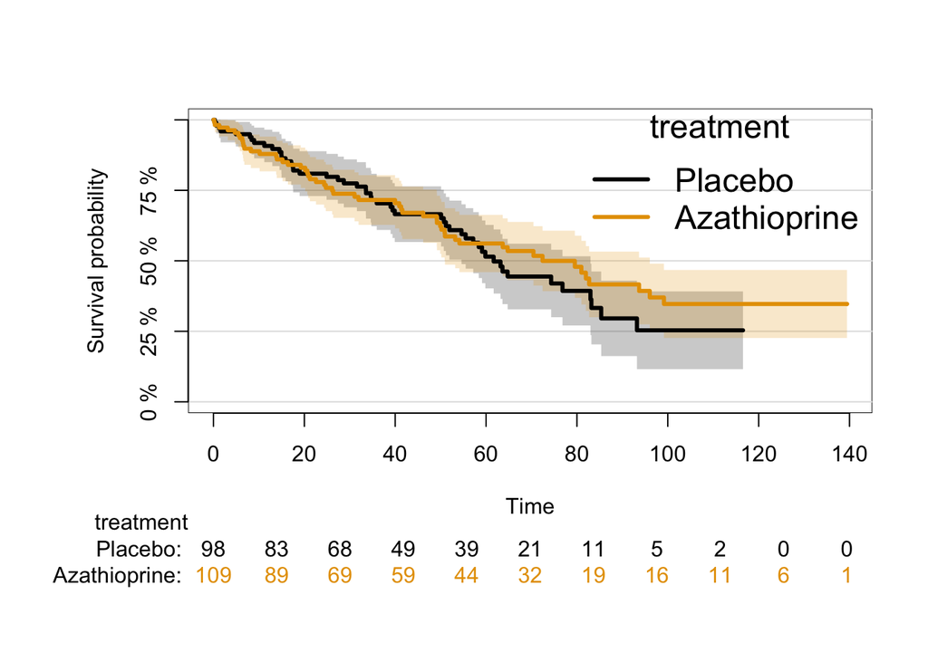

```r
plot(km1)
```

## b. Et test

Log-Rank test er det korrekte test her. Testet siger ikke noget om effektstørrelsen, kun om der er en forskel. Med en p-værdi i nærheden af 0.5 kan vi altså ikke afvise hypotesen om ingen forskel.

```r
survdiff(Surv(time_to_event, dead) ~ treatment, data = wr)
```

```
## Call:
## survdiff(formula = Surv(time_to_event, dead) ~ treatment, data = wr)
##
##                          N Observed Expected (O-E)^2/E (O-E)^2/V
## treatment=Placebo       98       50     46.6     0.253     0.469
## treatment=Azathioprine 109       53     56.4     0.209     0.469
##
##  Chisq= 0.5  on 1 degrees of freedom, p= 0.5
```

## c. Estimat for effektstørrelsen af azathioprin

```r
cox1 <- coxph(Surv(time_to_event, dead) ~ treatment, data = wr)
summary(cox1)
```

```
## Call:
## coxph(formula = Surv(time_to_event, dead) ~ treatment, data = wr)
##
##   n= 207, number of events= 103
##
##                          coef exp(coef) se(coef)      z Pr(>|z|)
## treatmentAzathioprine -0.1358    0.8730   0.1984 -0.684    0.494
##
##                       exp(coef) exp(-coef) lower .95 upper .95
## treatmentAzathioprine     0.873      1.145    0.5917     1.288
##
## Concordance= 0.503  (se = 0.027 )
## Likelihood ratio test= 0.47  on 1 df,   p=0.5
## Wald test            = 0.47  on 1 df,   p=0.5
## Score (logrank) test = 0.47  on 1 df,   p=0.5
```

```r
pretty_coef(cox1, trans = exp) # hazard ratio med CI-grænser for effekten af azathioprin
```

```
##                       Est. 2.5 % 97.5 %
## treatmentAzathioprine 0.87  0.59   1.29
```

```r
# Ny model med ændret reference i treatment factor
cox2 <- coxph(Surv(time_to_event, dead) ~ relevel(treatment, "Azathioprine"), data = wr)
pretty_coef(cox2, exp)
```

```
##                                           Est. 2.5 % 97.5 %
## relevel(treatment, "Azathioprine")Placebo 1.15  0.78   1.69
```

```r
exp(-pretty_coef(cox1)) # giver det samme pga. symmetri i parvis sammenligning
```

```
##                           Est.    2.5 %    97.5 %
## treatmentAzathioprine 1.150274 1.682028 0.7788008
```

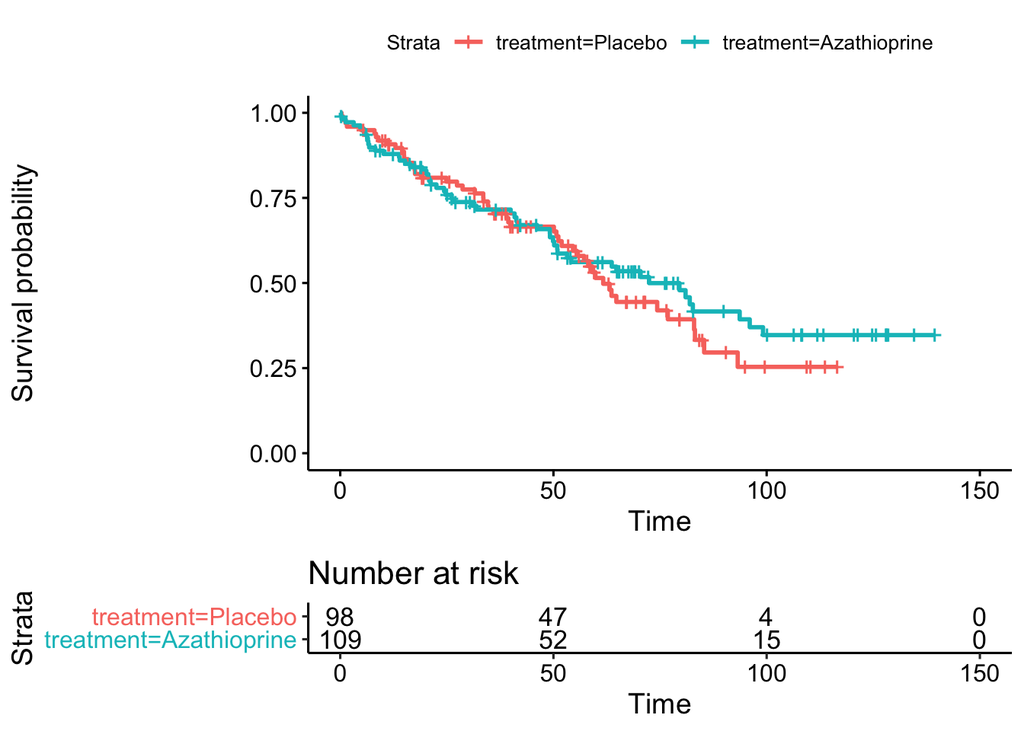

```r
# Alternativ fra survminer-pakken
#    kræver ekstra arbejde for at blive rigtigt godt men det kan det så også blive ift. base-graphics,
#    som prodlim-fittet ovenfor bruger
cox1_fit_alt <- surv_fit(Surv(time_to_event, dead) ~ treatment, data = wr)
ggsurvplot(cox1_fit_alt, risk.table = TRUE)
```

# Spørgsmål 2

## a. Er s-bilirubin skævt fordelt?

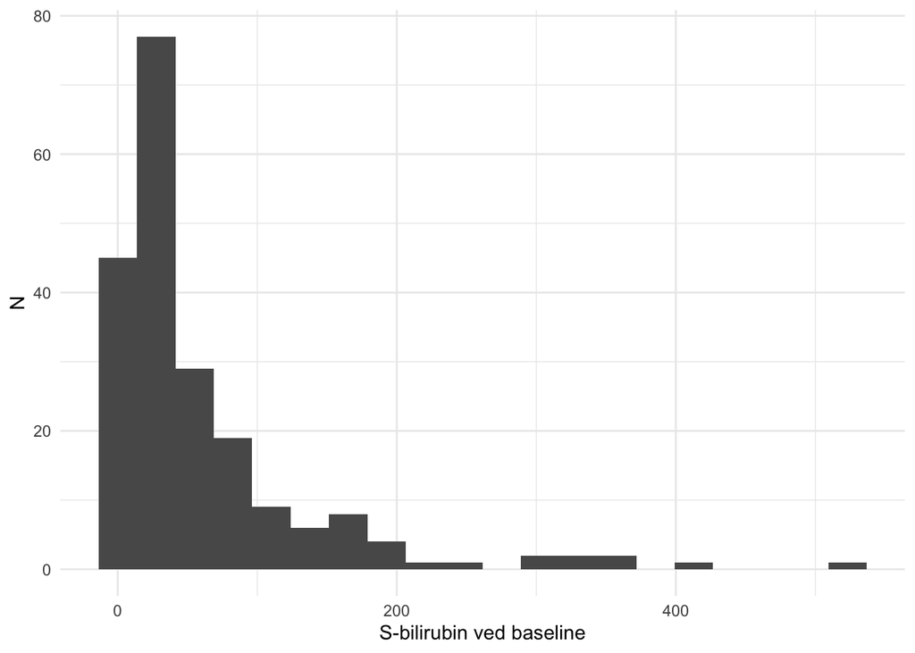

```r
# ggplot's histogram giver to måde at definere bredden: binwidth eller bins (antal)
qplot(wr$bl_bilirubin, bins = 20, xlab = "S-bilirubin ved baseline", ylab = "N")
```

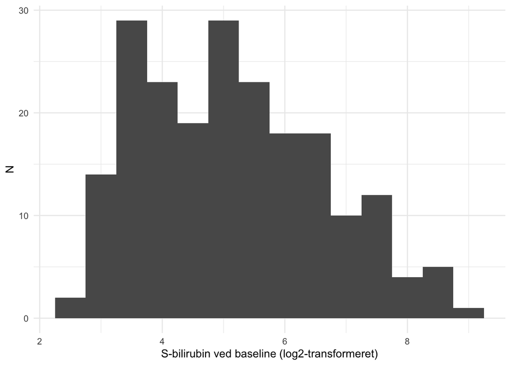

```r
qplot(wr$log2_bl_bilirubin, binwidth = 0.5, xlab = "S-bilirubin ved baseline (log2-transformeret)", ylab = "N")
```

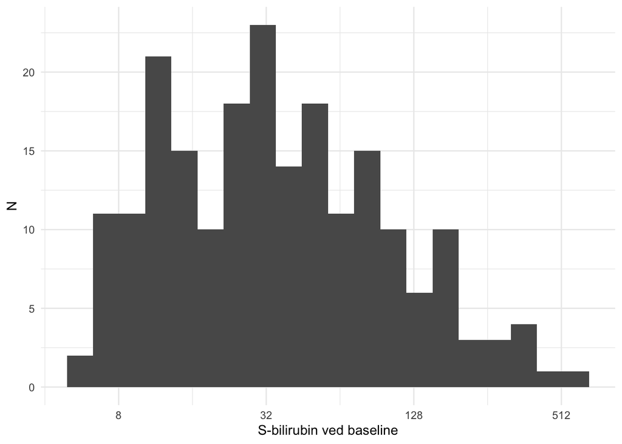

```r
# Alternative with actual values but on log2-scale
qplot(wr$bl_bilirubin, bins = 20, xlab = "S-bilirubin ved baseline", ylab = "N") +
    scale_x_continuous(trans = "log2")
```

- Den er temmeligt skæv
- Det gælder for mange biomarkører, da de ikke kan være lavere end 0, men der sagtens kan være stor spredning i højre side af fordelingen
- Skævheden i sig selv er ikke et problem (husk i regressioner er det ikke kovariaternes fordelinger der skal være normalfordelt, men derimod residualerne; mange går i vandet dér)
- Problemet med skæve fordelinger er derimod, at der kan være outliers, som får uforholdsmæssig stor betydning for estimaterne, fordi de trækker mere, end de burde. Dette kan føre til ustabile estimater: hvis én observation trækker rigtigt meget i estimaterne, ændres estimaterne meget, hvis denne ikke var blevet registreret (eller hvis den korrekte værdi var blevet registreret, hvis det viser sig at være en datafejl)
- Derudover er 1:1-ændringer ofte ikke de mest informative for skæve fordelinger: en ændring i s-bilirubin på 10 er mere biologisk relevant i den lave ende (fra f.eks. 10 til 20) end i den høje ende (fra 410 til 420)

## 2b. Hvilken “udgave” af s-bilirubin er bedst

Vi tager begge med i en model samtidigt, først i en model uden behandlingskovariaten, hvilket viser, at den log2-transformerede kovariat er klart mest informativ (p-værdi for associationen meget lavere end kovariaten på den oprindelige skala)

```r
cox2 <- coxph(Surv(time_to_event, dead) ~ bl_bilirubin + log2_bl_bilirubin, data = wr)
summary(cox2)
```

```
## Call:
## coxph(formula = Surv(time_to_event, dead) ~ bl_bilirubin + log2_bl_bilirubin,
##     data = wr)
##
##   n= 207, number of events= 103
##
##                        coef exp(coef)  se(coef)      z Pr(>|z|)
## bl_bilirubin      -0.001839  0.998163  0.001951 -0.943    0.346
## log2_bl_bilirubin  0.806816  2.240761  0.139753  5.773 7.78e-09 ***
## ---
## Signif. codes:  0 '***' 0.001 '**' 0.01 '*' 0.05 '.' 0.1 ' ' 1
##
##                   exp(coef) exp(-coef) lower .95 upper .95
## bl_bilirubin         0.9982     1.0018    0.9944     1.002
## log2_bl_bilirubin    2.2408     0.4463    1.7039     2.947
##
## Concordance= 0.776  (se = 0.022 )
## Likelihood ratio test= 91.39  on 2 df,   p=<2e-16
## Wald test            = 83.4  on 2 df,   p=<2e-16
## Score (logrank) test = 115.5  on 2 df,   p=<2e-16
```

Og analysen *med* behandlingsindikatoren giver samme billede (læg dog mærke til, at behandlingseffekt pludseligt er signifikant…)

```r
cox3 <- coxph(Surv(time_to_event, dead) ~ treatment + bl_bilirubin + log2_bl_bilirubin, data = wr)
summary(cox3)
```

```
## Call:
## coxph(formula = Surv(time_to_event, dead) ~ treatment + bl_bilirubin +
##     log2_bl_bilirubin, data = wr)
##
##   n= 207, number of events= 103
##
##                            coef exp(coef)  se(coef)      z Pr(>|z|)
## treatmentAzathioprine -0.509680  0.600688  0.205912 -2.475   0.0133 *
## bl_bilirubin          -0.001615  0.998387  0.001964 -0.822   0.4109
## log2_bl_bilirubin      0.841057  2.318818  0.142092  5.919 3.24e-09 ***
## ---
## Signif. codes:  0 '***' 0.001 '**' 0.01 '*' 0.05 '.' 0.1 ' ' 1
##
##                       exp(coef) exp(-coef) lower .95 upper .95
## treatmentAzathioprine    0.6007     1.6648    0.4012    0.8993
## bl_bilirubin             0.9984     1.0016    0.9946    1.0022
## log2_bl_bilirubin        2.3188     0.4313    1.7552    3.0635
##
## Concordance= 0.779  (se = 0.022 )
## Likelihood ratio test= 97.46  on 3 df,   p=<2e-16
## Wald test            = 87.05  on 3 df,   p=<2e-16
## Score (logrank) test = 120.1  on 3 df,   p=<2e-16
```

## 2c. Modellere effekten af baseline s-bilirubin vha. lineær spline

Vi har ikke rigtigt nogen god ide om, hvor spline-knudepunkterne skal være, så bruger kvartiler i stedet. Se også tabel 2.3 i *Frank Harrell - Regression modelling techniques*. Det er disse værdier, vi bruger til at definere vore data i toppen.

`linearHypothesis` tester, hvorvidt hældningerne af *alle* tre segmenter i den lineære spline er 0. Vi finder, der **ikke** er en lineær sammenhæng ($p \ll 0.001$), og vi bør altså ikke bruge `bl_bilirubin` direkte i modellen, da dette jo antager linearitet mellem denne kovariat og udfaldet. Som I ved, skal man altid regne før, vi må regne, så det husker vi lige at gøre også.

```r
quantile(filter(wr, event == "Dead")$bl_bilirubin, c(0.25, 0.5, 0.75))
```

```
##   25%   50%   75%
##  31.0  54.0 119.5
```

```r
cox4 <- coxph(Surv(time_to_event, dead) ~ treatment + bl_bilirubin + bl_bilirubin_p25 +
                bl_bilirubin_p50 + bl_bilirubin_p75, data = wr)
summary(cox4)
```

```
## Call:
## coxph(formula = Surv(time_to_event, dead) ~ treatment + bl_bilirubin +
##     bl_bilirubin_p25 + bl_bilirubin_p50 + bl_bilirubin_p75, data = wr)
##
##   n= 207, number of events= 103
##
##                            coef exp(coef)  se(coef)      z Pr(>|z|)
## treatmentAzathioprine -0.505522  0.603191  0.206863 -2.444 0.014535 *
## bl_bilirubin           0.076995  1.080036  0.021057  3.656 0.000256 ***
## bl_bilirubin_p25      -0.059958  0.941804  0.034022 -1.762 0.078014 .
## bl_bilirubin_p50      -0.002675  0.997328  0.022309 -0.120 0.904544
## bl_bilirubin_p75      -0.011002  0.989058  0.007031 -1.565 0.117604
## ---
## Signif. codes:  0 '***' 0.001 '**' 0.01 '*' 0.05 '.' 0.1 ' ' 1
##
##                       exp(coef) exp(-coef) lower .95 upper .95
## treatmentAzathioprine    0.6032     1.6579    0.4021    0.9048
## bl_bilirubin             1.0800     0.9259    1.0364    1.1255
## bl_bilirubin_p25         0.9418     1.0618    0.8811    1.0067
## bl_bilirubin_p50         0.9973     1.0027    0.9547    1.0419
## bl_bilirubin_p75         0.9891     1.0111    0.9755    1.0028
##
## Concordance= 0.779  (se = 0.022 )
## Likelihood ratio test= 96.19  on 5 df,   p=<2e-16
## Wald test            = 84.87  on 5 df,   p=<2e-16
## Score (logrank) test = 120.3  on 5 df,   p=<2e-16
```

```r
linearHypothesis(cox4, sprintf("bl_bilirubin_p%s = 0", c(25, 50, 75)))
```

```
## Linear hypothesis test
##
## Hypothesis:
## bl_bilirubin_p25 = 0
## bl_bilirubin_p50 = 0
## bl_bilirubin_p75 = 0
##
## Model 1: restricted model
## Model 2: Surv(time_to_event, dead) ~ treatment + bl_bilirubin + bl_bilirubin_p25 +
##     bl_bilirubin_p50 + bl_bilirubin_p75
##
##   Res.Df Df Chisq Pr(>Chisq)
## 1    205
## 2    202  3 34.18  1.816e-07 ***
## ---
## Signif. codes:  0 '***' 0.001 '**' 0.01 '*' 0.05 '.' 0.1 ' ' 1
```

```r
# Alternativ med lsp (lsp = linear spline) fra rms-pakken (kræver kun knudepunkter; intet behov for ekstra datakolonner)
cox4a <- coxph(Surv(time_to_event, dead) ~ treatment + lsp(bl_bilirubin, c(31, 54, 119.5)), data = wr)

cox4b <- coxph(Surv(time_to_event, dead) ~ treatment + log2_bl_bilirubin + lsp(log2_bl_bilirubin, log2(c(31, 54, 119.5))), data = wr)
summary(cox4a)
```

```
## Call:
## coxph(formula = Surv(time_to_event, dead) ~ treatment + lsp(bl_bilirubin,
##     c(31, 54, 119.5)), data = wr)
##
##   n= 207, number of events= 103
##
##                                                         coef exp(coef)  se(coef)      z Pr(>|z|)
## treatmentAzathioprine                              -0.505522  0.603191  0.206863 -2.444 0.014535
## lsp(bl_bilirubin, c(31, 54, 119.5))bl_bilirubin     0.076995  1.080036  0.021057  3.656 0.000256
## lsp(bl_bilirubin, c(31, 54, 119.5))bl_bilirubin'   -0.059958  0.941804  0.034022 -1.762 0.078014
## lsp(bl_bilirubin, c(31, 54, 119.5))bl_bilirubin''  -0.002675  0.997328  0.022309 -0.120 0.904544
## lsp(bl_bilirubin, c(31, 54, 119.5))bl_bilirubin''' -0.011002  0.989058  0.007031 -1.565 0.117604
##
## treatmentAzathioprine                              *
## lsp(bl_bilirubin, c(31, 54, 119.5))bl_bilirubin    ***
## lsp(bl_bilirubin, c(31, 54, 119.5))bl_bilirubin'   .
## lsp(bl_bilirubin, c(31, 54, 119.5))bl_bilirubin''
## lsp(bl_bilirubin, c(31, 54, 119.5))bl_bilirubin'''
## ---
## Signif. codes:  0 '***' 0.001 '**' 0.01 '*' 0.05 '.' 0.1 ' ' 1
##
##                                                    exp(coef) exp(-coef) lower .95 upper .95
## treatmentAzathioprine                                 0.6032     1.6579    0.4021    0.9048
## lsp(bl_bilirubin, c(31, 54, 119.5))bl_bilirubin       1.0800     0.9259    1.0364    1.1255
## lsp(bl_bilirubin, c(31, 54, 119.5))bl_bilirubin'      0.9418     1.0618    0.8811    1.0067
## lsp(bl_bilirubin, c(31, 54, 119.5))bl_bilirubin''     0.9973     1.0027    0.9547    1.0419
## lsp(bl_bilirubin, c(31, 54, 119.5))bl_bilirubin'''    0.9891     1.0111    0.9755    1.0028
##
## Concordance= 0.779  (se = 0.022 )
## Likelihood ratio test= 96.19  on 5 df,   p=<2e-16
## Wald test            = 84.87  on 5 df,   p=<2e-16
## Score (logrank) test = 120.3  on 5 df,   p=<2e-16
```

```r
linearHypothesis(cox4a, sprintf("lsp(bl_bilirubin, c(31, 54, 119.5))bl_bilirubin%s = 0", c("'", "''", "'''")))
```

```
## Linear hypothesis test
##
## Hypothesis:
## lsp(bl_bilirubin, c(31, 54, 119.5))bl_bilirubin' = 0
## lsp(bl_bilirubin, c(31, 54, 119.5))bl_bilirubin'' = 0
## lsp(bl_bilirubin, c(31, 54, 119.5))bl_bilirubin''' = 0
##
## Model 1: restricted model
## Model 2: Surv(time_to_event, dead) ~ treatment + lsp(bl_bilirubin, c(31,
##     54, 119.5))
##
##   Res.Df Df Chisq Pr(>Chisq)
## 1    205
## 2    202  3 34.18  1.816e-07 ***
## ---
## Signif. codes:  0 '***' 0.001 '**' 0.01 '*' 0.05 '.' 0.1 ' ' 1
```

```r
summary(cox4b)
```

```
## Call:
## coxph(formula = Surv(time_to_event, dead) ~ treatment + log2_bl_bilirubin +
##     lsp(log2_bl_bilirubin, log2(c(31, 54, 119.5))), data = wr)
##
##   n= 207, number of events= 103
##
##                                                                        coef exp(coef) se(coef)
## treatmentAzathioprine                                              -0.50537   0.60328  0.20662
## log2_bl_bilirubin                                                   0.99887   2.71520  0.29242
## lsp(log2_bl_bilirubin, log2(c(31, 54, 119.5)))log2_bl_bilirubin          NA        NA  0.00000
## lsp(log2_bl_bilirubin, log2(c(31, 54, 119.5)))log2_bl_bilirubin'   -0.35268   0.70281  0.71726
## lsp(log2_bl_bilirubin, log2(c(31, 54, 119.5)))log2_bl_bilirubin''  -0.01422   0.98588  0.82680
## lsp(log2_bl_bilirubin, log2(c(31, 54, 119.5)))log2_bl_bilirubin'''  0.08534   1.08908  0.56495
##                                                                         z Pr(>|z|)
## treatmentAzathioprine                                              -2.446 0.014447 *
## log2_bl_bilirubin                                                   3.416 0.000636 ***
## lsp(log2_bl_bilirubin, log2(c(31, 54, 119.5)))log2_bl_bilirubin        NA       NA
## lsp(log2_bl_bilirubin, log2(c(31, 54, 119.5)))log2_bl_bilirubin'   -0.492 0.622933
## lsp(log2_bl_bilirubin, log2(c(31, 54, 119.5)))log2_bl_bilirubin''  -0.017 0.986279
## lsp(log2_bl_bilirubin, log2(c(31, 54, 119.5)))log2_bl_bilirubin'''  0.151 0.879934
## ---
## Signif. codes:  0 '***' 0.001 '**' 0.01 '*' 0.05 '.' 0.1 ' ' 1
##
##                                                                    exp(coef) exp(-coef) lower .95
## treatmentAzathioprine                                                 0.6033     1.6576    0.4024
## log2_bl_bilirubin                                                     2.7152     0.3683    1.5307
## lsp(log2_bl_bilirubin, log2(c(31, 54, 119.5)))log2_bl_bilirubin           NA         NA        NA
## lsp(log2_bl_bilirubin, log2(c(31, 54, 119.5)))log2_bl_bilirubin'      0.7028     1.4229    0.1723
## lsp(log2_bl_bilirubin, log2(c(31, 54, 119.5)))log2_bl_bilirubin''     0.9859     1.0143    0.1950
## lsp(log2_bl_bilirubin, log2(c(31, 54, 119.5)))log2_bl_bilirubin'''    1.0891     0.9182    0.3599
##                                                                    upper .95
## treatmentAzathioprine                                                 0.9045
## log2_bl_bilirubin                                                     4.8163
## lsp(log2_bl_bilirubin, log2(c(31, 54, 119.5)))log2_bl_bilirubin           NA
## lsp(log2_bl_bilirubin, log2(c(31, 54, 119.5)))log2_bl_bilirubin'      2.8666
## lsp(log2_bl_bilirubin, log2(c(31, 54, 119.5)))log2_bl_bilirubin''     4.9842
## lsp(log2_bl_bilirubin, log2(c(31, 54, 119.5)))log2_bl_bilirubin'''    3.2957
##
## Concordance= 0.779  (se = 0.022 )
## Likelihood ratio test= 97.84  on 5 df,   p=<2e-16
## Wald test            = 85.28  on 5 df,   p=<2e-16
## Score (logrank) test = 123.8  on 5 df,   p=<2e-16
```

Det kræver lidt forarbejde at lave plottet, men det er relativt hurtigt klaret. Det ligner temmeligt meget effekten, vi fandt med log2-transformationen, hvilken er en del lettere at arbejde med.

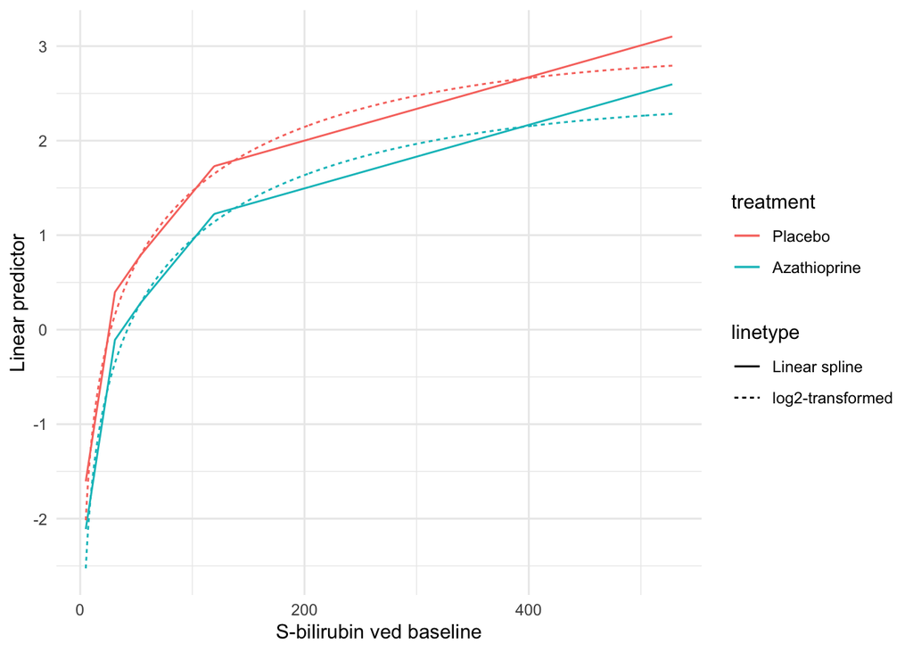

```r
make_spline <- function(x, knot) {
    (x - knot) * (x > knot)
}
plot_df <- expand.grid(treatment = c("Placebo", "Azathioprine"),
                       bl_bilirubin = min(wr$bl_bilirubin):max(wr$bl_bilirubin)) %>%
    mutate(bl_bilirubin_p25 = make_spline(bl_bilirubin, 31),
           bl_bilirubin_p50 = make_spline(bl_bilirubin, 54),
           bl_bilirubin_p75 = make_spline(bl_bilirubin, 119.5),
           log2_bl_bilirubin = log2(bl_bilirubin)) %>%
    ddply("treatment",
          function(d) mutate(d, lin_pred_cox4 = predict(cox4, newdata = d, type = "lp"),
                           lin_pred_cox3 = predict(cox3, newdata = d, type = "lp")))

ggplot(plot_df, aes(x = bl_bilirubin, colour = treatment)) +
    geom_line(aes(y = lin_pred_cox4, linetype = "Linear spline")) +
    geom_line(aes(y = lin_pred_cox3, linetype = "log2-transformed")) +
    labs(x = "S-bilirubin ved baseline", y = "Linear predictor")
```

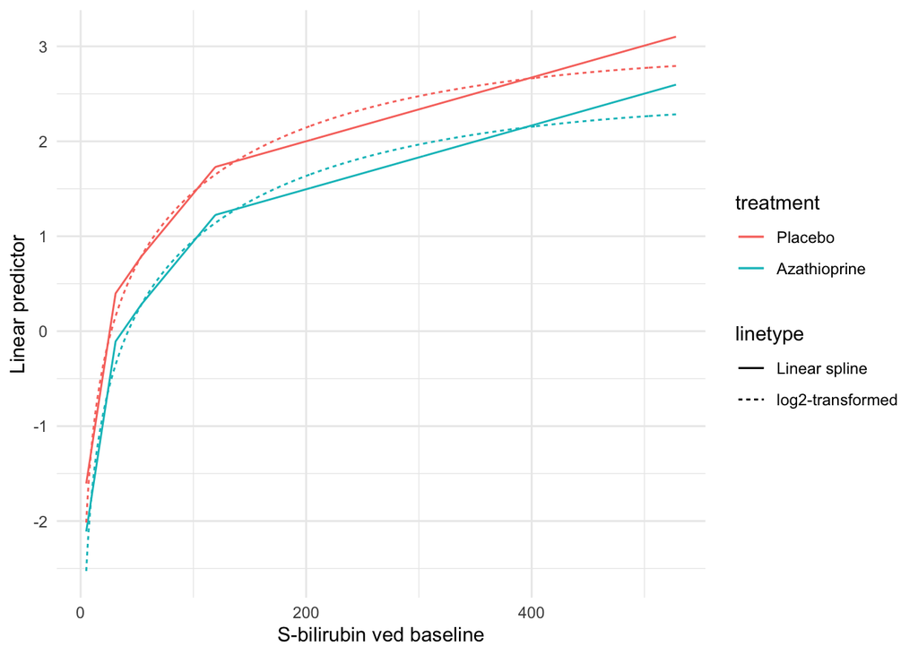

```r
# Alternativ hvis vi havde brugt lsp i stedet for selv at lave spline-variable
plot_df2 <- expand.grid(treatment = c("Placebo", "Azathioprine"),
                       bl_bilirubin = min(wr$bl_bilirubin):max(wr$bl_bilirubin)) %>%
    mutate(log2_bl_bilirubin = log2(bl_bilirubin)) %>%
    ddply("treatment",
          function(d) mutate(d, lin_pred_cox4 = predict(cox4a, newdata = d, type = "lp"),
                           lin_pred_cox3 = predict(cox3, newdata = d, type = "lp")))

ggplot(plot_df2, aes(x = bl_bilirubin, colour = treatment)) + # plot-delen er helt mage til ovenfor
    geom_line(aes(y = lin_pred_cox4, linetype = "Linear spline")) +
    geom_line(aes(y = lin_pred_cox3, linetype = "log2-transformed")) +
    labs(x = "S-bilirubin ved baseline", y = "Linear predictor")
```

# Spørgsmål 3 + 4

Resultaterne ovenfor mere end antyder, at en log2-transformation af s-bilirubin ved baseline er den rette tilgang. log2-transformationen er også lettere at arbejde med end den lineære spline. Fortolkning: en fordobling i s-bilirubin ved baseline er associeret med godt og vel en fordobling i dødsraten. Dette ændrer også ved resultatet af hovedanalysen: effekten af azathioprin, som nu sænker dødsraten til 59% af dødsraten blandt placebobehandlede patienter *med samme s-bilirubin ved baseline*.

```r
cox6 <- coxph(Surv(time_to_event, dead) ~ azathiop + log2_bl_bilirubin, data = wr)
summary(cox6)
```

```
## Call:
## coxph(formula = Surv(time_to_event, dead) ~ azathiop + log2_bl_bilirubin,
##     data = wr)
##
##   n= 207, number of events= 103
##
##                      coef exp(coef) se(coef)      z Pr(>|z|)
## azathiop          -0.5201    0.5945   0.2061 -2.524   0.0116 *
## log2_bl_bilirubin  0.7425    2.1012   0.0773  9.605   <2e-16 ***
## ---
## Signif. codes:  0 '***' 0.001 '**' 0.01 '*' 0.05 '.' 0.1 ' ' 1
##
##                   exp(coef) exp(-coef) lower .95 upper .95
## azathiop             0.5945     1.6822    0.3969    0.8903
## log2_bl_bilirubin    2.1011     0.4759    1.8058    2.4449
##
## Concordance= 0.778  (se = 0.022 )
## Likelihood ratio test= 96.74  on 2 df,   p=<2e-16
## Wald test            = 92.26  on 2 df,   p=<2e-16
## Score (logrank) test = 103.6  on 2 df,   p=<2e-16
```

```r
pretty_coef(cox6, exp)
```

```
##                   Est. 2.5 % 97.5 %
## azathiop          0.59  0.40   0.89
## log2_bl_bilirubin 2.10  1.81   2.44
```

# Spørgsmål 5

Se også pointer i officielle besvarelse. Lad os lave en stratificeret tabel (dette bør jo egentligt være noget af det første, man gør).

```r
CreateTableOne(c("event", "time_to_event", "bl_bilirubin", "log2_bl_bilirubin"),
               strata = "treatment", data = wr) %>%
    print(catDigits = 0, contDigits = 1, test = FALSE, nonnormal = c("time_to_event", "bl_bilirubin"))
```

```
##                                Stratified by treatment
##                                 Placebo           Azathioprine
##   n                               98               109
##   event = Dead (%)                50 (51)           53 (49)
##   time_to_event (median [IQR])  42.8 [19.3, 66.5] 49.1 [20.2, 76.2]
##   bl_bilirubin (median [IQR])   30.0 [16.0, 59.5] 39.0 [15.0, 86.0]
##   log2_bl_bilirubin (mean (SD))  5.0 (1.4)         5.3 (1.6)
```

# Spørgsmål 6: Model-kontrol for Cox-modellen

## a. Grafisk kontrol af PH-antagelse

- Linierne bør være parallelle på cloglog-skalaen
- Flere overkrydsninger frem til 60 måneder (= bryder egentligt proportional-hazards-antagelse)
- Varierende afstand mellem kurverne
- Men mest ligger de nok oven i hinanden, hvilket jo også er en måde at være parallelle på

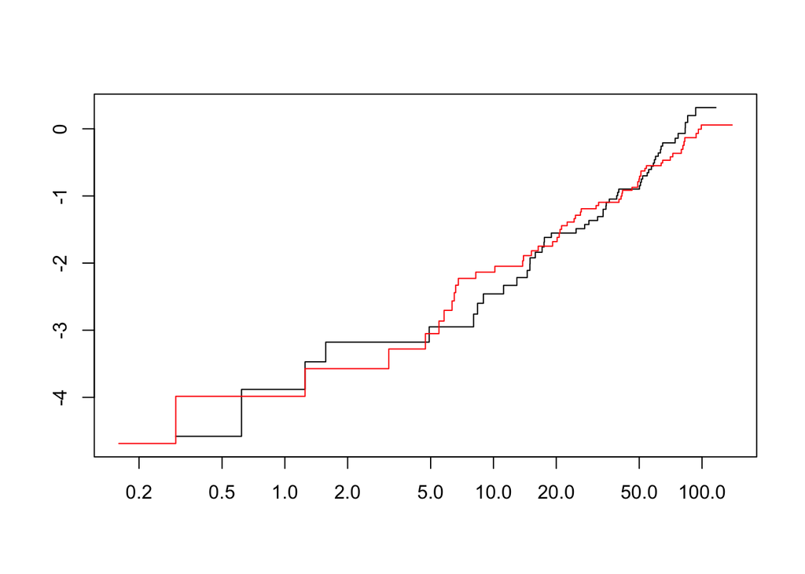

```r
survfit(Surv(time_to_event, dead) ~ treatment, data = wr) %>%
    plot(col = 1:2, fun = "cloglog")
```

## b. Grafisk kontrol af effekten af bilirubin

Vi er nødt til at inddele værdierne i nogle grupper, og vi vælger 33- og 67-percentilerne. Dette er allerede gjort øverst, så vi holder al datamanipulation ét sted. Vi har set fordelingen af denne variabel tidligere med `summary(wr)`.

```r
cox7 <- coxph(Surv(time_to_event, dead) ~ treatment + strata(bl_bilirubin_binned), data = wr)
summary(cox7)
```

```
## Call:
## coxph(formula = Surv(time_to_event, dead) ~ treatment + strata(bl_bilirubin_binned),
##     data = wr)
##
##   n= 207, number of events= 103
##
##                          coef exp(coef) se(coef)      z Pr(>|z|)
## treatmentAzathioprine -0.4414    0.6432   0.2047 -2.156   0.0311 *
## ---
## Signif. codes:  0 '***' 0.001 '**' 0.01 '*' 0.05 '.' 0.1 ' ' 1
##
##                       exp(coef) exp(-coef) lower .95 upper .95
## treatmentAzathioprine    0.6432      1.555    0.4306    0.9606
##
## Concordance= 0.549  (se = 0.03 )
## Likelihood ratio test= 4.62  on 1 df,   p=0.03
## Wald test            = 4.65  on 1 df,   p=0.03
## Score (logrank) test = 4.72  on 1 df,   p=0.03
```

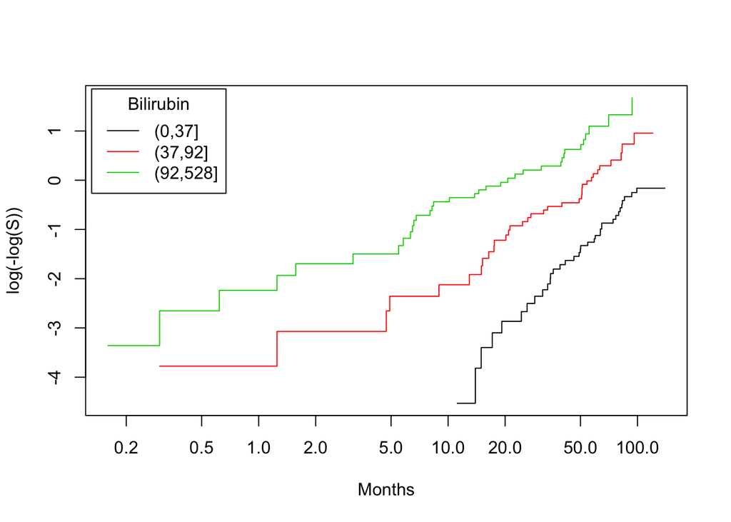

```r
survfit7 <- survfit(cox7, newdata = data.frame(treatment = "Placebo"))
plot(survfit7, fun = "cloglog", ylab = "log(-log(S))", col = 1:3, mark.time = FALSE, xlab = "Months")
legend("topleft", levels(wr$bl_bilirubin_binned), lty = 1, col = 1:3, title = "Bilirubin", inset = .01)
```

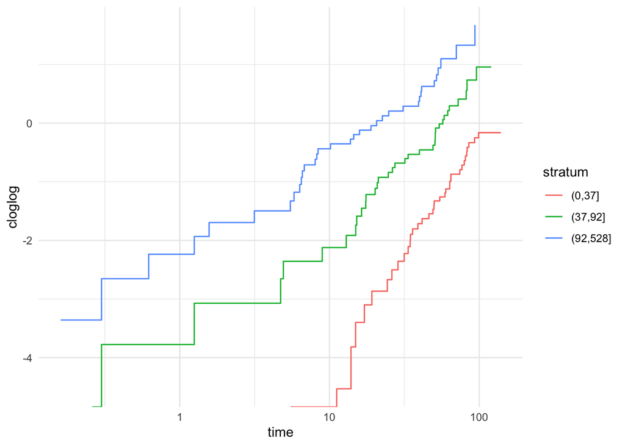

```r
# Alternativt plot
plot_df <- tibble(time = survfit7$time,
                  survival = survfit7$surv,
                  stratum = unlist(alply(survfit7$strata, 1, function(.) rep(names(.), .)))) %>%
    mutate(cloglog = log(-log(survival)))
ggplot(plot_df, aes(time, cloglog, colour = stratum)) +
    geom_step() +
    scale_x_continuous(trans = "log10")
```

## c.-e.

```r
set.seed(42)
ca1 <- cox.aalen(Surv(time_to_event, dead) ~ prop(treatment) + prop(log2_bl_bilirubin), data = wr)
summary(ca1)
```

```
## Cox-Aalen Model
##
## Test for Aalen terms
## Test not computed, sim=0
##
## Proportional Cox terms :
##                              Coef.     SE Robust SE D2log(L)^-1     z  P-val lower2.5% upper97.5%
## prop(treatment)Azathioprine -0.520 0.2070    0.2040      0.2060 -2.55 0.0107    -0.926     -0.114
## prop(log2_bl_bilirubin)      0.743 0.0708    0.0661      0.0773 11.20 0.0000     0.604      0.882
## Test of Proportionality
##                             sup|  hat U(t) | p-value H_0
## prop(treatment)Azathioprine             4.69        0.280
## prop(log2_bl_bilirubin)                11.90        0.226
```

`p-value H_0` giver ret høje p-værdier for proportionale rater, hvilket ikke tyder på, at denne antagelse er brudt. Det samme indtryk får vi at det tilsvarende plot; de kumulative residualer skal gerne ligge og danse rundt omring 0. De ligger lidt højt i starten, hvilket tyder på, patienter med høje værdier for disse (= de behandlede og dem med høje bilirubin-tal ved baseline) dør “for hurtigt” i starten.

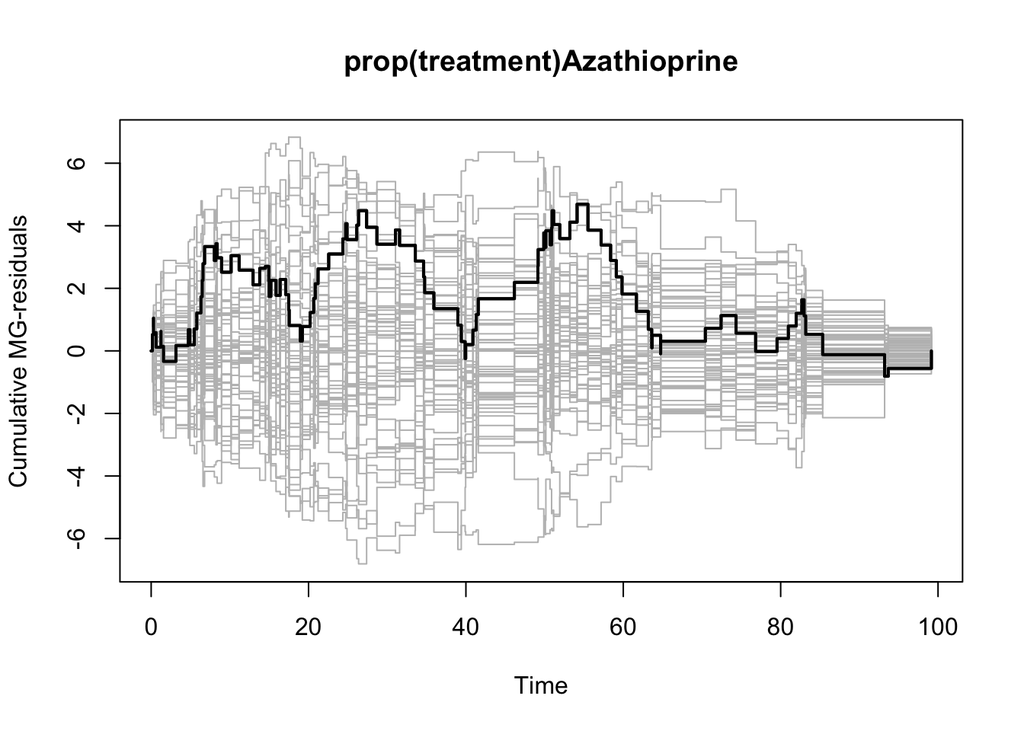

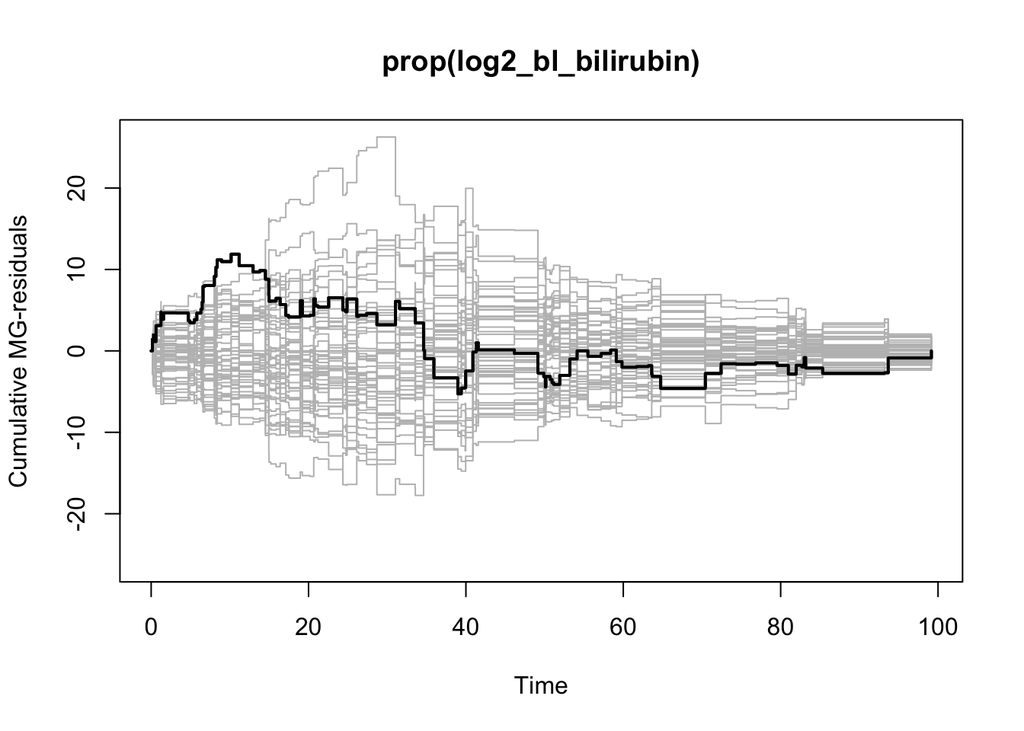

```r
plot(ca1, score = TRUE)
```

Da `log2_bl_bilirubin` er en kontinuert kovariat, ønsker vi et formelt test af dennes linearitet, som giver en p-værdi på ca. 85%, hvilket ikke tyder på problemer. Der ser ikke ud til at være mønstre i plottet, hvilket passer godt med linearitetsantagelsen.

```r
set.seed(42 )
ca2 <- cox.aalen(Surv(time_to_event, dead) ~ prop(treatment) + prop(log2_bl_bilirubin), data = wr,
                 residuals = 1, n.sim = 0)
resids <- cum.residuals(ca2, cum.resid = 1, data = wr)
summary(resids)
```

```
## Test for cumulative MG-residuals
##
## Grouped cumulative residuals not computed, you must provide
## modelmatrix to get these (see help)
##
## Residual versus covariates consistent with model
##
##                         sup|  hat B(t) | p-value H_0: B(t)=0
## prop(log2_bl_bilirubin)            4.161               0.866
```

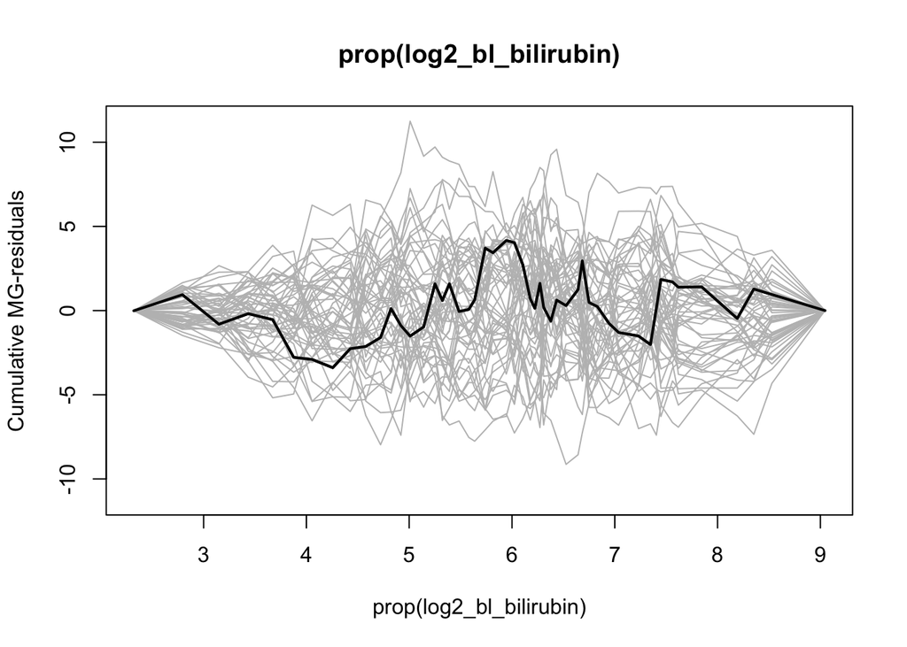

```r
plot(resids, score = 2)
```

### Med tidsafhængig effekt af azathioprin

```r
tt_fun_az <- function(x, t, ...) { # denne laver 3 vinduer
    cbind(dt1 = (x == "Azathioprine") * (t <= 12), # dt = delta time, time period
          dt2 = (x == "Azathioprine") * (12 < t & t <= 56),
          dt3 = (x == "Azathioprine") * (t > 56))
}

cox8 <- coxph(Surv(time_to_event, dead) ~ tt(treatment) + log2_bl_bilirubin, data = wr, tt = tt_fun_az)
summary(cox8)
```

```
## Call:
## coxph(formula = Surv(time_to_event, dead) ~ tt(treatment) + log2_bl_bilirubin,
##     data = wr, tt = tt_fun_az)
##
##   n= 207, number of events= 103
##
##                       coef exp(coef) se(coef)      z Pr(>|z|)
## tt(treatment)dt1  -0.04899   0.95219  0.43589 -0.112  0.91052
## tt(treatment)dt2  -0.42944   0.65088  0.27472 -1.563  0.11801
## tt(treatment)dt3  -1.15536   0.31495  0.41058 -2.814  0.00489 **
## log2_bl_bilirubin  0.74406   2.10446  0.07756  9.593  < 2e-16 ***
## ---
## Signif. codes:  0 '***' 0.001 '**' 0.01 '*' 0.05 '.' 0.1 ' ' 1
##
##                   exp(coef) exp(-coef) lower .95 upper .95
## tt(treatment)dt1     0.9522     1.0502    0.4052    2.2375
## tt(treatment)dt2     0.6509     1.5364    0.3799    1.1152
## tt(treatment)dt3     0.3149     3.1752    0.1408    0.7042
## log2_bl_bilirubin    2.1045     0.4752    1.8077    2.4500
##
## Concordance= 0.781  (se = 0.022 )
## Likelihood ratio test= 100.5  on 4 df,   p=<2e-16
## Wald test            = 95.47  on 4 df,   p=<2e-16
## Score (logrank) test = 107.4  on 4 df,   p=<2e-16
```

```r
linearHypothesis(cox8, c("tt(treatment)dt1 = tt(treatment)dt2","tt(treatment)dt2 = tt(treatment)dt3"))
```

```
## Linear hypothesis test
##
## Hypothesis:
## tt(treatment)dt1 - tt(treatment)dt2 = 0
## tt(treatment)dt2 - tt(treatment)dt3 = 0
##
## Model 1: restricted model
## Model 2: Surv(time_to_event, dead) ~ tt(treatment) + log2_bl_bilirubin
##
##   Res.Df Df  Chisq Pr(>Chisq)
## 1    205
## 2    203  2 3.7292      0.155
```

### Med tidsafhængig effekt af baseline s-bilirubin

```r
quantile(filter(wr, dead == 1)$time_to_event, 1:2 / 3) # to find cut points for changing hazard ratios
```

```
## 33.33333% 66.66667%
##     18.95     50.16
```

```r
tt_fun_lb <- function(x, t, ...) { # denne laver 3 vinduer vha. cut points fundet ovenfor
    cbind(dt1 = x * (t <= 19), # dt = delta time, time period
          dt2 = x * (19 < t & t <= 50),
          dt3 = x * (t > 50))
}

cox9 <- coxph(Surv(time_to_event, dead) ~ treatment + tt(log2_bl_bilirubin), data = wr, tt = tt_fun_lb)
summary(cox9)
```

```
## Call:
## coxph(formula = Surv(time_to_event, dead) ~ treatment + tt(log2_bl_bilirubin),
##     data = wr, tt = tt_fun_lb)
##
##   n= 207, number of events= 103
##
##                             coef exp(coef) se(coef)      z Pr(>|z|)
## treatmentAzathioprine    -0.5065    0.6026   0.2062 -2.457    0.014 *
## tt(log2_bl_bilirubin)dt1  0.8258    2.2837   0.1190  6.937 4.00e-12 ***
## tt(log2_bl_bilirubin)dt2  0.5891    1.8024   0.1294  4.553 5.28e-06 ***
## tt(log2_bl_bilirubin)dt3  0.8130    2.2548   0.1533  5.304 1.14e-07 ***
## ---
## Signif. codes:  0 '***' 0.001 '**' 0.01 '*' 0.05 '.' 0.1 ' ' 1
##
##                          exp(coef) exp(-coef) lower .95 upper .95
## treatmentAzathioprine       0.6026     1.6595    0.4023    0.9026
## tt(log2_bl_bilirubin)dt1    2.2837     0.4379    1.8085    2.8837
## tt(log2_bl_bilirubin)dt2    1.8024     0.5548    1.3987    2.3227
## tt(log2_bl_bilirubin)dt3    2.2548     0.4435    1.6696    3.0450
##
## Concordance= 0.778  (se = 0.022 )
## Likelihood ratio test= 98.91  on 4 df,   p=<2e-16
## Wald test            = 92.97  on 4 df,   p=<2e-16
## Score (logrank) test = 105.8  on 4 df,   p=<2e-16
```

```r
linearHypothesis( cox9, c("tt(log2_bl_bilirubin)dt1 = tt(log2_bl_bilirubin)dt2",
                          "tt(log2_bl_bilirubin)dt2 = tt(log2_bl_bilirubin)dt3"))
```

```
## Linear hypothesis test
##
## Hypothesis:
## tt(log2_bl_bilirubin)dt1 - tt(log2_bl_bilirubin)dt2 = 0
## tt(log2_bl_bilirubin)dt2 - tt(log2_bl_bilirubin)dt3 = 0
##
## Model 1: restricted model
## Model 2: Surv(time_to_event, dead) ~ treatment + tt(log2_bl_bilirubin)
##
##   Res.Df Df Chisq Pr(>Chisq)
## 1    205
## 2    203  2 2.162     0.3392
```